# Statistical comparison of DNA Isolation Methods across each Library preparation protocol, Toti samples - analyzed with minitax on all NCBI genomes DB

Balázs Kakuk

# 1 Notes

- Minitax was run in BestAln method
- In minitax, reads were *NOT* filtered for MAPQ
- In minitax, results were *NOT* normalized to Genome Size
- Unclassified reads *were* excluded
- Taxa with total reads number of 10 or lower were excluded
- Eukaryotes were *NOT* excluded from the analyis
- Same samples for different sequencing dates were combined
- The statistical tests were carried out on sample-wise Bray-Curtis distances

# 2 Bray-Curtis distance-based statistical tests on DNA isolation kits in each Vregion (and platform)

*PERMIDISP is a multivariate analysis of the homogeneity of groups dispersions (variances), which can be used as a means of assessing beta diversity.*

*PERMANOVA: Permutational Multivariate Analysis of Variance Using Distance Matrices*

## 2.1 V1-V2

### 2.1.1 PERMANOVA

|  | Df | SumOfSqs | R2 | F | Pr(>F) |
| --- | --- | --- | --- | --- | --- |
| DNA_isolation_method | 2 | 0.3473101 | 0.7896974 | 16.89774 | 0.001 |
| Residual | 9 | 0.0924914 | 0.2103026 | NA | NA |
| Total | 11 | 0.4398016 | 1.0000000 | NA | NA |

```
##     pairs Df  SumsOfSqs   F.Model        R2 p.value p.adjusted sig
## 1 I vs MN  1 0.01561086  1.883981 0.2389631   0.099      0.297
## 2  I vs Z  1 0.27008712 24.829658 0.8053822   0.033      0.099
## 3 MN vs Z  1 0.23526723 20.165582 0.7706911   0.029      0.087
```

### 2.1.2 PERMDISP2

```
##
##  Homogeneity of multivariate dispersions
##
## Call: betadisper(d = dis, group = groups)
##
## No. of Positive Eigenvalues: 10
## No. of Negative Eigenvalues: 1
##
## Average distance to median:
##       I      MN       Z
## 0.07389 0.08179 0.10210
##
## Eigenvalues for PCoA axes:
## (Showing 8 of 11 eigenvalues)
##    PCoA1    PCoA2    PCoA3    PCoA4    PCoA5    PCoA6    PCoA7    PCoA8
## 0.340987 0.029880 0.022364 0.017643 0.012903 0.006415 0.003574 0.003321
```

### 2.1.3 ANOVA on test results

|  | Df | Sum Sq | Mean Sq | F value | Pr(>F) |
| --- | --- | --- | --- | --- | --- |
| Groups | 2 | 0.0016946 | 0.0008473 | 2.678057 | 0.1222997 |
| Residuals | 9 | 0.0028475 | 0.0003164 | NA | NA |

### 2.1.4 Permutation test for F

```
##
## Permutation test for homogeneity of multivariate dispersions
## Permutation: free
## Number of permutations: 9999
##
## Response: Distances
##           Df    Sum Sq    Mean Sq      F N.Perm Pr(>F)
## Groups     2 0.0016946 0.00084731 2.6781   9999 0.1238
## Residuals  9 0.0028475 0.00031639
##
## Pairwise comparisons:
## (Observed p-value below diagonal, permuted p-value above diagonal)
##           I       MN      Z
## I           0.497300 0.0807
## MN 0.494353          0.1613
## Z  0.088018 0.164347
```

### 2.1.5 Tukey’s Honest Significant Differences

```
##   Tukey multiple comparisons of means
##     95% family-wise confidence level
##
## Fit: aov(formula = distances ~ group, data = df)
##
## $group
##             diff          lwr        upr     p adj
## MN-I 0.007899617 -0.027217077 0.04301631 0.8088094
## Z-I  0.028212591 -0.006904103 0.06332929 0.1167253
## Z-MN 0.020312974 -0.014803720 0.05542967 0.2886726
```

### 2.1.6 PCoA and distances to centroid for each group

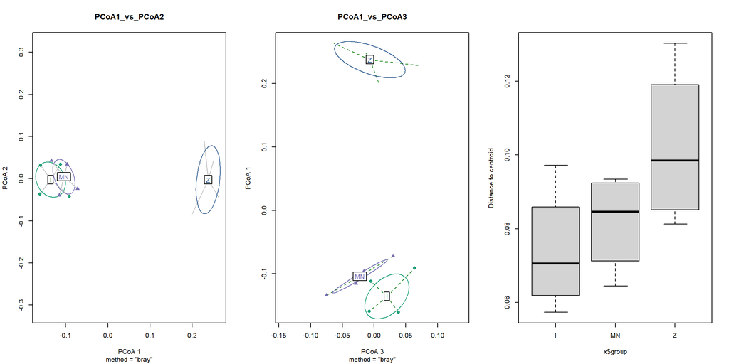

## 2.2 V1-V3

### 2.2.1 PERMANOVA

|  | Df | SumOfSqs | R2 | F | Pr(>F) |
| --- | --- | --- | --- | --- | --- |
| DNA_isolation_method | 3 | 1.5841525 | 0.630205 | 6.248737 | 0.001 |
| Residual | 11 | 0.9295573 | 0.369795 | NA | NA |
| Total | 14 | 2.5137098 | 1.000000 | NA | NA |

```
##     pairs Df  SumsOfSqs    F.Model         R2 p.value p.adjusted sig
## 1 I vs MN  1 0.03210425  0.3993622 0.06240657   0.949      1.000
## 2  I vs Q  1 1.05007662 15.8992653 0.76075714   0.022      0.132
## 3  I vs Z  1 0.33653695  3.9370062 0.39619641   0.025      0.150
## 4 MN vs Q  1 0.98230801 11.7874666 0.70215875   0.028      0.168
## 5 MN vs Z  1 0.31286849  3.1321863 0.34298318   0.083      0.498
## 6  Q vs Z  1 0.58335970  6.5219993 0.56604754   0.026      0.156
```

### 2.2.2 PERMDISP2

```
##
##  Homogeneity of multivariate dispersions
##
## Call: betadisper(d = dis, group = groups)
##
## No. of Positive Eigenvalues: 13
## No. of Negative Eigenvalues: 1
##
## Average distance to median:
##      I     MN      Q      Z
## 0.2165 0.2450 0.1939 0.2740
##
## Eigenvalues for PCoA axes:
## (Showing 8 of 14 eigenvalues)
##   PCoA1   PCoA2   PCoA3   PCoA4   PCoA5   PCoA6   PCoA7   PCoA8
## 1.34202 0.54043 0.25152 0.11441 0.06802 0.05525 0.04519 0.03759
```

### 2.2.3 ANOVA on test results

|  | Df | Sum Sq | Mean Sq | F value | Pr(>F) |
| --- | --- | --- | --- | --- | --- |
| Groups | 3 | 0.0129254 | 0.0043085 | 0.3111101 | 0.8170199 |
| Residuals | 11 | 0.1523356 | 0.0138487 | NA | NA |

### 2.2.4 Permutation test for F

```
##
## Permutation test for homogeneity of multivariate dispersions
## Permutation: free
## Number of permutations: 999
##
## Response: Distances
##           Df   Sum Sq   Mean Sq      F N.Perm Pr(>F)
## Groups     3 0.012925 0.0043085 0.3111    999  0.806
## Residuals 11 0.152336 0.0138487
##
## Pairwise comparisons:
## (Observed p-value below diagonal, permuted p-value above diagonal)
##          I      MN       Q     Z
## I          0.72300 0.79300 0.400
## MN 0.74730         0.64800 0.734
## Q  0.80739 0.65069         0.400
## Z  0.43039 0.74343 0.40551
```

### 2.2.5 Tukey’s Honest Significant Differences

```
##   Tukey multiple comparisons of means
##     95% family-wise confidence level
##
## Fit: aov(formula = distances ~ group, data = df)
##
## $group
##             diff        lwr       upr     p adj
## MN-I  0.02849502 -0.2219375 0.2789275 0.9854477
## Q-I  -0.02265784 -0.2931558 0.2478402 0.9940460
## Z-I   0.05747138 -0.1929611 0.3079039 0.8985339
## Q-MN -0.05115286 -0.3216509 0.2193451 0.9392324
## Z-MN  0.02897635 -0.2214561 0.2794088 0.9847263
## Z-Q   0.08012922 -0.1903688 0.3506272 0.8094041
```

### 2.2.6 PCoA and distances to centroid for each group

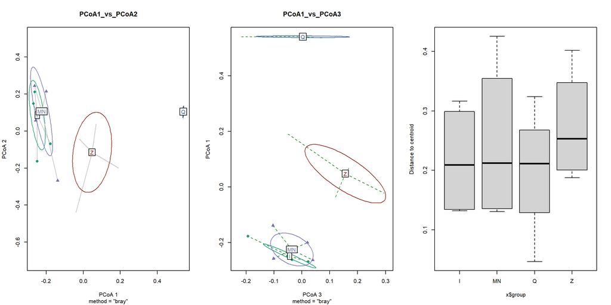

## 2.3 V3-V4

### 2.3.1 PERMANOVA

|  | Df | SumOfSqs | R2 | F | Pr(>F) |
| --- | --- | --- | --- | --- | --- |
| DNA_isolation_method | 2 | 0.3057377 | 0.8347609 | 22.73327 | 0.001 |
| Residual | 9 | 0.0605201 | 0.1652391 | NA | NA |
| Total | 11 | 0.3662578 | 1.0000000 | NA | NA |

```
##     pairs Df   SumsOfSqs  F.Model        R2 p.value p.adjusted sig
## 1 I vs MN  1 0.009769035  1.90312 0.2408062   0.124      0.372
## 2  I vs Z  1 0.236089010 33.60838 0.8485169   0.031      0.093
## 3 MN vs Z  1 0.212748492 26.54217 0.8156238   0.020      0.060
```

### 2.3.2 PERMDISP2

```
##
##  Homogeneity of multivariate dispersions
##
## Call: betadisper(d = dis, group = groups)
##
## No. of Positive Eigenvalues: 10
## No. of Negative Eigenvalues: 1
##
## Average distance to median:
##       I      MN       Z
## 0.05480 0.06476 0.08440
##
## Eigenvalues for PCoA axes:
## (Showing 8 of 11 eigenvalues)
##    PCoA1    PCoA2    PCoA3    PCoA4    PCoA5    PCoA6    PCoA7    PCoA8
## 0.308030 0.022634 0.017309 0.008380 0.004854 0.002732 0.002024 0.001282
```

### 2.3.3 ANOVA on test results

|  | Df | Sum Sq | Mean Sq | F value | Pr(>F) |
| --- | --- | --- | --- | --- | --- |
| Groups | 2 | 0.0018142 | 0.0009071 | 1.790261 | 0.2215376 |
| Residuals | 9 | 0.0045600 | 0.0005067 | NA | NA |

### 2.3.4 Permutation test for F

```
##
## Permutation test for homogeneity of multivariate dispersions
## Permutation: free
## Number of permutations: 999
##
## Response: Distances
##           Df    Sum Sq    Mean Sq      F N.Perm Pr(>F)
## Groups     2 0.0018142 0.00090708 1.7903    999  0.209
## Residuals  9 0.0045600 0.00050667
##
## Pairwise comparisons:
## (Observed p-value below diagonal, permuted p-value above diagonal)
##           I       MN     Z
## I           0.523000 0.103
## MN 0.535626          0.290
## Z  0.086186 0.315795
```

### 2.3.5 Tukey’s Honest Significant Differences

```
##   Tukey multiple comparisons of means
##     95% family-wise confidence level
##
## Fit: aov(formula = distances ~ group, data = df)
##
## $group
##             diff         lwr        upr     p adj
## MN-I 0.009952489 -0.03448656 0.05439154 0.8102895
## Z-I  0.029593662 -0.01484539 0.07403271 0.2057444
## Z-MN 0.019641172 -0.02479788 0.06408022 0.4641729
```

### 2.3.6 PCoA and distances to centroid for each group

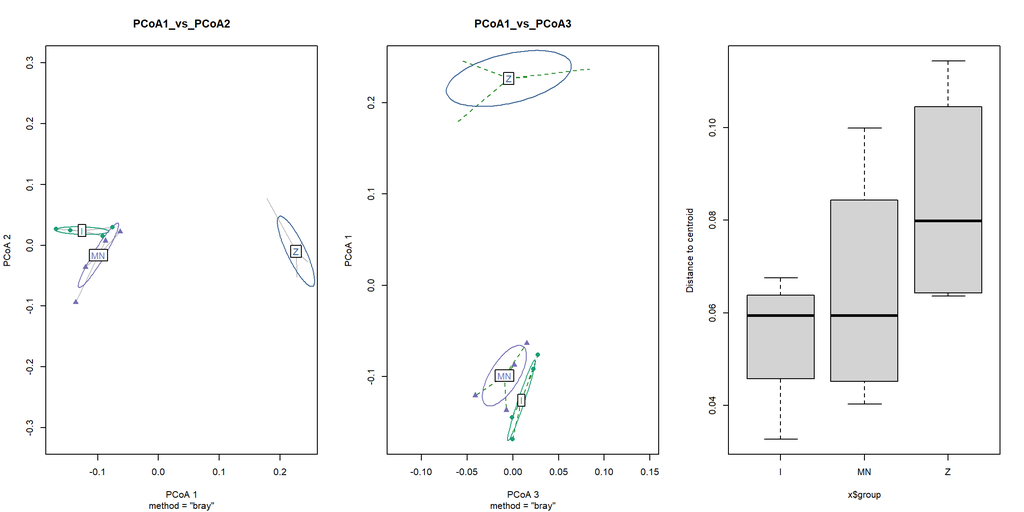

## 2.4 V1-V9 ONT

### 2.4.1 PERMANOVA

|  | Df | SumOfSqs | R2 | F | Pr(>F) |
| --- | --- | --- | --- | --- | --- |
| DNA_isolation_method | 2 | 0.4931191 | 0.7912401 | 17.05586 | 0.001 |
| Residual | 9 | 0.1301040 | 0.2087599 | NA | NA |
| Total | 11 | 0.6232231 | 1.0000000 | NA | NA |

```
##     pairs Df SumsOfSqs   F.Model        R2 p.value p.adjusted sig
## 1 I vs MN  1 0.0144123  4.849683 0.4469885   0.036      0.108
## 2  I vs Z  1 0.3777522 19.136233 0.7613007   0.023      0.069
## 3 MN vs Z  1 0.3475141 16.823847 0.7371171   0.037      0.111
```

### 2.4.2 PERMDISP2

```
##
##  Homogeneity of multivariate dispersions
##
## Call: betadisper(d = dis, group = groups)
##
## No. of Positive Eigenvalues: 9
## No. of Negative Eigenvalues: 2
##
## Average distance to median:
##       I      MN       Z
## 0.03669 0.05028 0.16618
##
## Eigenvalues for PCoA axes:
## (Showing 8 of 11 eigenvalues)
##     PCoA1     PCoA2     PCoA3     PCoA4     PCoA5     PCoA6     PCoA7     PCoA8
## 0.4857621 0.0915264 0.0204710 0.0148776 0.0076347 0.0030724 0.0014532 0.0006946
```

### 2.4.3 ANOVA on test results

|  | Df | Sum Sq | Mean Sq | F value | Pr(>F) |
| --- | --- | --- | --- | --- | --- |
| Groups | 2 | 0.0405142 | 0.0202571 | 29.89881 | 0.0001059 |
| Residuals | 9 | 0.0060977 | 0.0006775 | NA | NA |

### 2.4.4 Permutation test for F

```
##
## Permutation test for homogeneity of multivariate dispersions
## Permutation: free
## Number of permutations: 999
##
## Response: Distances
##           Df   Sum Sq   Mean Sq      F N.Perm Pr(>F)
## Groups     2 0.040514 0.0202571 29.899    999  0.001 ***
## Residuals  9 0.006098 0.0006775
## ---
## Signif. codes:  0 '***' 0.001 '**' 0.01 '*' 0.05 '.' 0.1 ' ' 1
##
## Pairwise comparisons:
## (Observed p-value below diagonal, permuted p-value above diagonal)
##             I         MN     Z
## I             0.42700000 0.002
## MN 0.45482549            0.003
## Z  0.00027897 0.00142140
```

### 2.4.5 Tukey’s Honest Significant Differences

```
##   Tukey multiple comparisons of means
##     95% family-wise confidence level
##
## Fit: aov(formula = distances ~ group, data = df)
##
## $group
##            diff         lwr        upr     p adj
## MN-I 0.01358951 -0.03779866 0.06497768 0.7478330
## Z-I  0.12949084  0.07810267 0.18087901 0.0001608
## Z-MN 0.11590133  0.06451316 0.16728950 0.0003719
```

### 2.4.6 PCoA and distances to centroid for each group

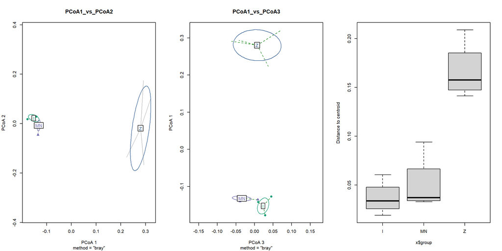

## 2.5 V1-V9 PacBio

### 2.5.1 PERMANOVA

|  | Df | SumOfSqs | R2 | F | Pr(>F) |
| --- | --- | --- | --- | --- | --- |
| DNA_isolation_method | 2 | 0.6088595 | 0.8385104 | 23.36557 | 0.001 |
| Residual | 9 | 0.1172609 | 0.1614896 | NA | NA |
| Total | 11 | 0.7261204 | 1.0000000 | NA | NA |

```
##     pairs Df  SumsOfSqs   F.Model        R2 p.value p.adjusted sig
## 1 I vs MN  1 0.03743297  8.327012 0.5812106   0.034      0.102
## 2  I vs Z  1 0.48376230 28.799532 0.8275839   0.034      0.102
## 3 MN vs Z  1 0.39209399 22.035158 0.7859830   0.022      0.066
```

### 2.5.2 PERMDISP2

```
##
##  Homogeneity of multivariate dispersions
##
## Call: betadisper(d = dis, group = groups)
##
## No. of Positive Eigenvalues: 8
## No. of Negative Eigenvalues: 3
##
## Average distance to median:
##       I      MN       Z
## 0.04774 0.05943 0.14883
##
## Eigenvalues for PCoA axes:
## (Showing 8 of 11 eigenvalues)
##     PCoA1     PCoA2     PCoA3     PCoA4     PCoA5     PCoA6     PCoA7     PCoA8
## 0.5944311 0.0635758 0.0372018 0.0145211 0.0112279 0.0080022 0.0012869 0.0003957
```

### 2.5.3 ANOVA on test results

|  | Df | Sum Sq | Mean Sq | F value | Pr(>F) |
| --- | --- | --- | --- | --- | --- |
| Groups | 2 | 0.0244651 | 0.0122326 | 12.48712 | 0.0025346 |
| Residuals | 9 | 0.0088165 | 0.0009796 | NA | NA |

### 2.5.4 Permutation test for F

```
##
## Permutation test for homogeneity of multivariate dispersions
## Permutation: free
## Number of permutations: 999
##
## Response: Distances
##           Df    Sum Sq   Mean Sq      F N.Perm Pr(>F)
## Groups     2 0.0244651 0.0122326 12.487    999  0.012 *
## Residuals  9 0.0088165 0.0009796
## ---
## Signif. codes:  0 '***' 0.001 '**' 0.01 '*' 0.05 '.' 0.1 ' ' 1
##
## Pairwise comparisons:
## (Observed p-value below diagonal, permuted p-value above diagonal)
##            I        MN     Z
## I            0.5860000 0.011
## MN 0.6162148           0.016
## Z  0.0033616 0.0076370
```

### 2.5.5 Tukey’s Honest Significant Differences

```
##   Tukey multiple comparisons of means
##     95% family-wise confidence level
##
## Fit: aov(formula = distances ~ group, data = df)
##
## $group
##            diff         lwr        upr     p adj
## MN-I 0.01169008 -0.05010147 0.07348164 0.8597197
## Z-I  0.10109176  0.03930021 0.16288332 0.0034662
## Z-MN 0.08940168  0.02761012 0.15119323 0.0074162
```

### 2.5.6 PCoA and distances to centroid for each group

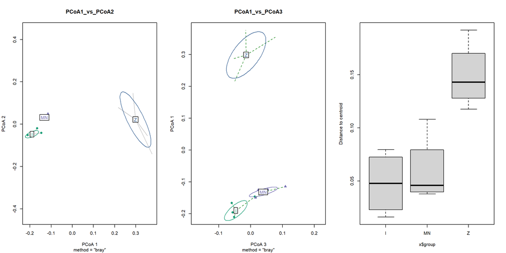

## 2.6 WGS

### 2.6.1 PERMANOVA

|  | Df | SumOfSqs | R2 | F | Pr(>F) |
| --- | --- | --- | --- | --- | --- |
| DNA_isolation_method | 3 | 1.9900761 | 0.9544186 | 83.75505 | 0.001 |
| Residual | 12 | 0.0950427 | 0.0455814 | NA | NA |
| Total | 15 | 2.0851188 | 1.0000000 | NA | NA |

```
##     pairs Df  SumsOfSqs    F.Model        R2 p.value p.adjusted sig
## 1 I vs MN  1 0.02737042   4.646445 0.4364316   0.030      0.180
## 2  I vs Q  1 1.26583277 399.366978 0.9851986   0.022      0.132
## 3  I vs Z  1 0.25491919  26.043691 0.8127557   0.033      0.198
## 4 MN vs Q  1 1.28389535 212.133060 0.9724939   0.033      0.198
## 5 MN vs Z  1 0.21342334  16.843649 0.7373449   0.021      0.126
## 6  Q vs Z  1 0.93471113  93.942404 0.9399654   0.027      0.162
```

### 2.6.2 PERMDISP2

```
##
##  Homogeneity of multivariate dispersions
##
## Call: betadisper(d = dis, group = groups)
##
## No. of Positive Eigenvalues: 11
## No. of Negative Eigenvalues: 4
##
## Average distance to median:
##       I      MN       Q       Z
## 0.04298 0.07497 0.04624 0.09735
##
## Eigenvalues for PCoA axes:
## (Showing 8 of 15 eigenvalues)
##    PCoA1    PCoA2    PCoA3    PCoA4    PCoA5    PCoA6    PCoA7    PCoA8
## 1.769347 0.255407 0.036020 0.016829 0.010180 0.008521 0.002884 0.002152
```

### 2.6.3 ANOVA on test results

|  | Df | Sum Sq | Mean Sq | F value | Pr(>F) |
| --- | --- | --- | --- | --- | --- |
| Groups | 3 | 0.0079300 | 0.0026433 | 1.320899 | 0.3132258 |
| Residuals | 12 | 0.0240138 | 0.0020012 | NA | NA |

### 2.6.4 Permutation test for F

```
##
## Permutation test for homogeneity of multivariate dispersions
## Permutation: free
## Number of permutations: 999
##
## Response: Distances
##           Df   Sum Sq   Mean Sq      F N.Perm Pr(>F)
## Groups     3 0.007930 0.0026433 1.3209    999  0.335
## Residuals 12 0.024014 0.0020012
##
## Pairwise comparisons:
## (Observed p-value below diagonal, permuted p-value above diagonal)
##          I      MN       Q     Z
## I          0.28300 0.89500 0.219
## MN 0.26788         0.27500 0.625
## Q  0.86913 0.27715         0.217
## Z  0.19956 0.60076 0.20827
```

### 2.6.5 Tukey’s Honest Significant Differences

```
##   Tukey multiple comparisons of means
##     95% family-wise confidence level
##
## Fit: aov(formula = distances ~ group, data = df)
##
## $group
##              diff         lwr        upr     p adj
## MN-I  0.031992610 -0.06191928 0.12590450 0.7460596
## Q-I   0.003256443 -0.09065544 0.09716833 0.9995863
## Z-I   0.054372396 -0.03953949 0.14828428 0.3563655
## Q-MN -0.028736167 -0.12264805 0.06517572 0.8007950
## Z-MN  0.022379786 -0.07153210 0.11629167 0.8921990
## Z-Q   0.051115953 -0.04279593 0.14502784 0.4063988
```

### 2.6.6 PCoA and distances to centroid for each group

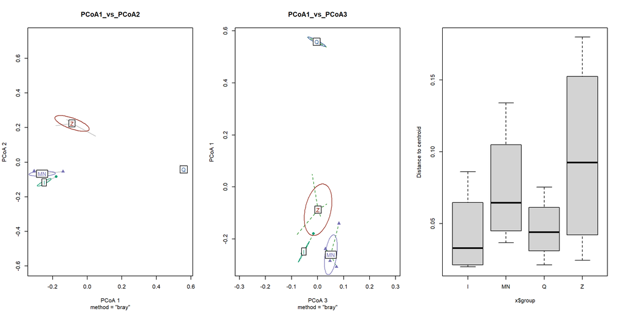

## 2.7 Combined plots for the results each library separetely

### 2.7.1 PCoA

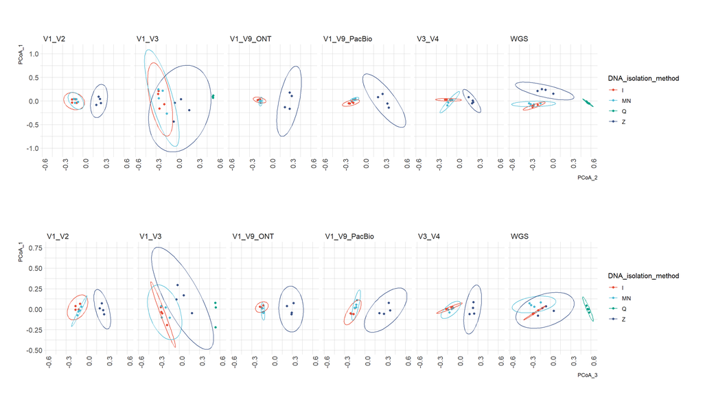

### 2.7.2 Boxplot of distance to centroids

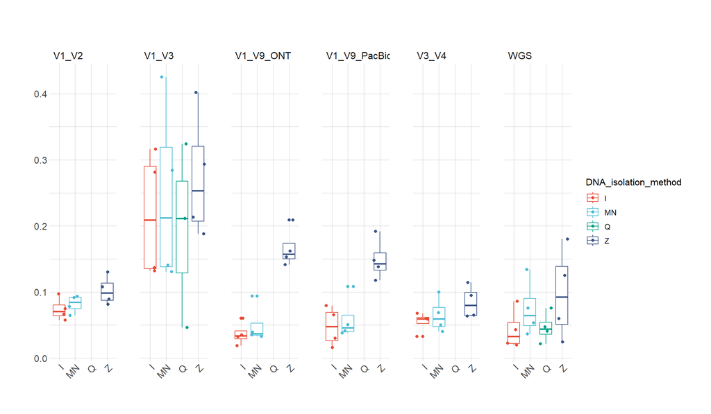

| DNA_isolation_method | Vregion.x | mean_distance | sd_distance |
| --- | --- | --- | --- |
| I | V1_V2 | 0.0738868 | 0.0170628 |
| I | V1_V3 | 0.2165217 | 0.0960299 |
| I | V1_V9_ONT | 0.0366937 | 0.0173147 |
| I | V1_V9_PacBio | 0.0477392 | 0.0296292 |
| I | V3_V4 | 0.0548046 | 0.0152123 |
| I | WGS | 0.0429824 | 0.0305603 |
| MN | V1_V2 | 0.0817864 | 0.0134379 |
| MN | V1_V3 | 0.2450167 | 0.1389492 |
| MN | V1_V9_ONT | 0.0502833 | 0.0292870 |
| MN | V1_V9_PacBio | 0.0594292 | 0.0328670 |
| MN | V3_V4 | 0.0647571 | 0.0262072 |
| MN | WGS | 0.0749750 | 0.0425692 |
| Q | V1_V3 | 0.1938638 | 0.1395282 |
| Q | WGS | 0.0462388 | 0.0223741 |
| Z | V1_V2 | 0.1020994 | 0.0218508 |
| Z | V1_V3 | 0.2739930 | 0.0962870 |
| Z | V1_V9_ONT | 0.1661846 | 0.0295810 |
| Z | V1_V9_PacBio | 0.1488309 | 0.0313165 |
| Z | V3_V4 | 0.0843982 | 0.0245313 |
| Z | WGS | 0.0973548 | 0.0689777 |

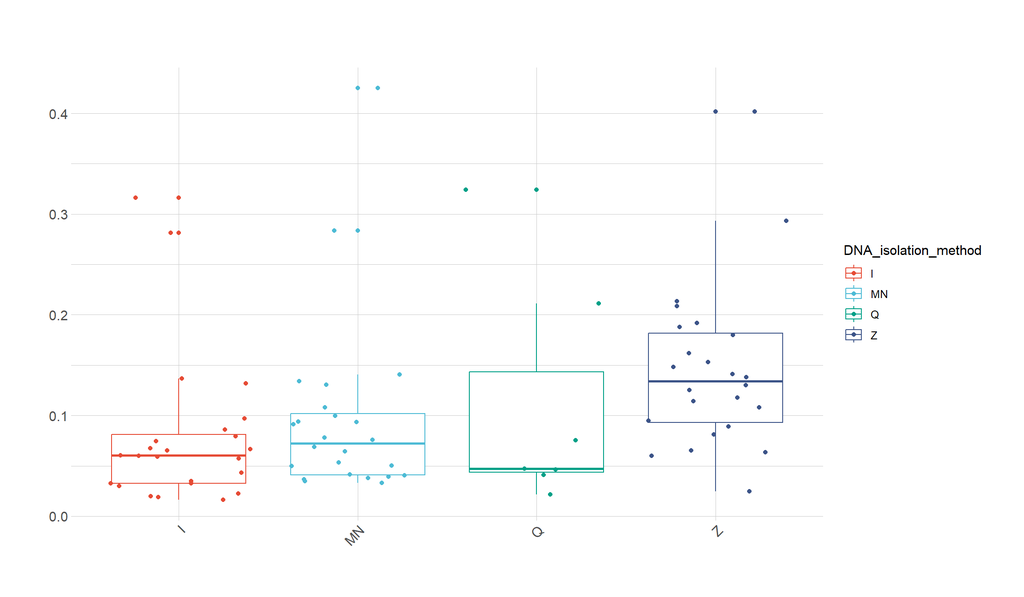

| DNA_isolation_method | mean_distance | sd_distance |
| --- | --- | --- |
| I | 0.0787714 | 0.0751575 |
| MN | 0.0960413 | 0.0886585 |
| Q | 0.1095067 | 0.1138696 |
| Z | 0.1454768 | 0.0808730 |

### 2.7.3 PERMANOVA

PERMANOVA (Permutational Multivariate Analysis of Variance) is a method to test the hypothesis that groups defined by some factor have similar multivariate dispersions and centroids. It’s a non-parametric alternative to MANOVA and is particularly suited for community data in ecology. It works by comparing the distance between groups to the distance within groups.

The null hypothesis is that the centroids of the groups in the multivariate space are equal. If the p-value is small (typically below 0.05), we reject the null hypothesis, suggesting the group centroids are indeed different.

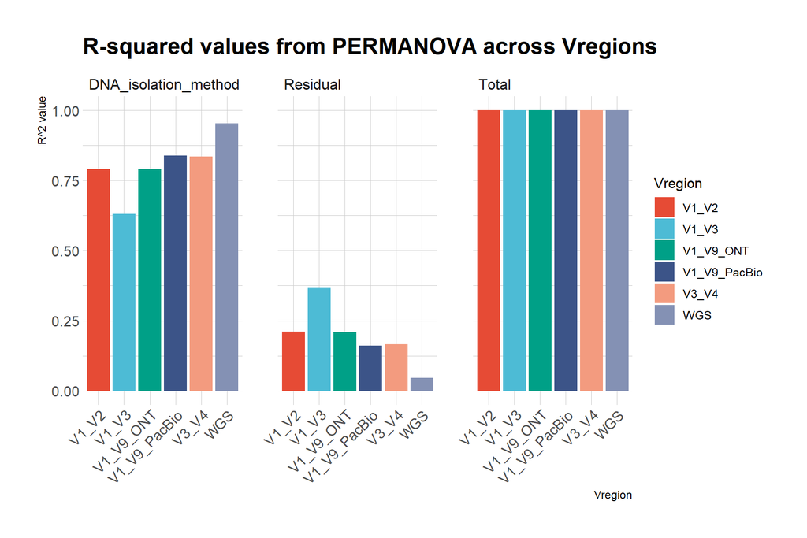

The R2 values indicate the proportion of variation explained by the groups. A higher R2 suggests that the grouping factor (in this case, the DNA isolation method) explains a larger proportion of the variation in the data.

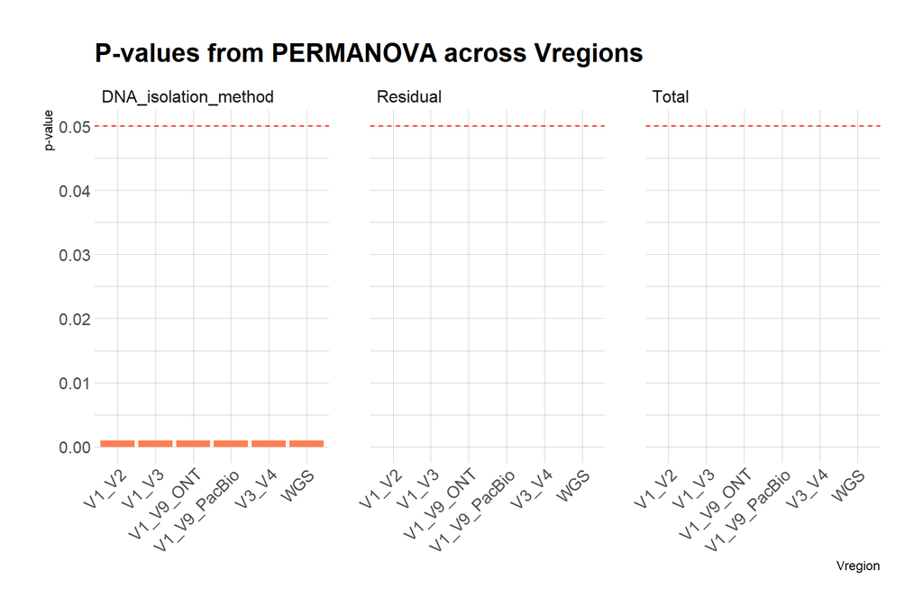

A p-value less than 0.05, indicate that the centroids of the groups in the multivariate space are significantly different.

### 2.7.4 Pair-Wise PERMANOVA

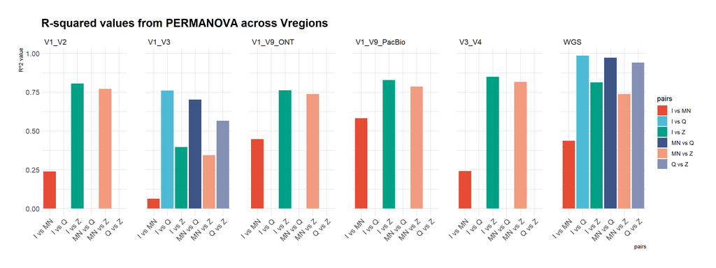

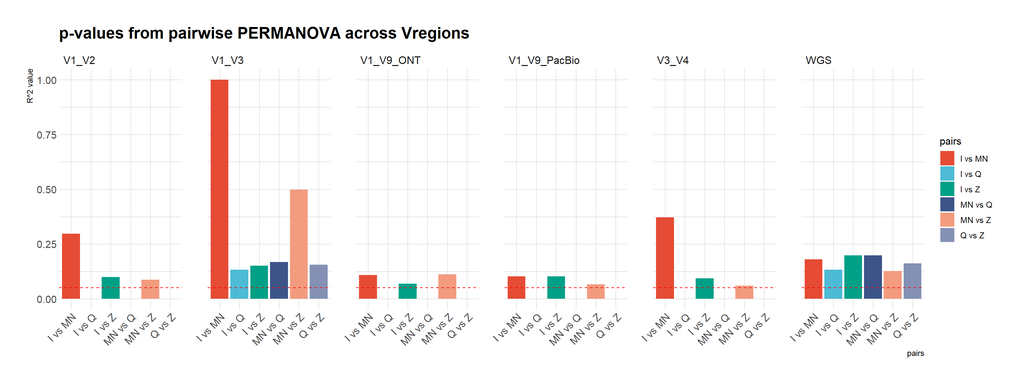

### 2.7.5 PERMUTEST

The permutation test is a non-parametric method used to determine the significance of observed results by comparing them to a distribution of results obtained through random shuffling (or permutations) of the data labels. In the context of community ecology and the PERMANOVA test, a permutation test can be employed to determine if observed differences between groups are significant compared to differences obtained by randomly assigning samples to groups.

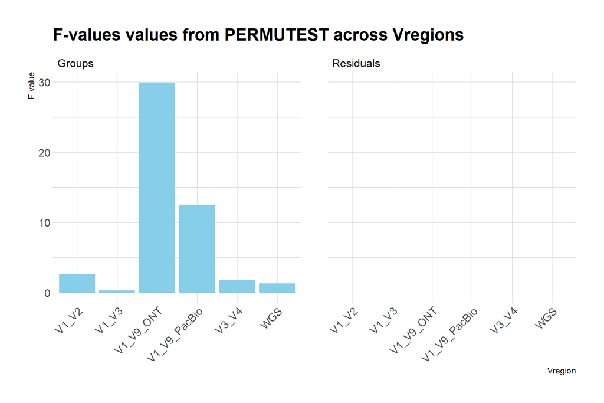

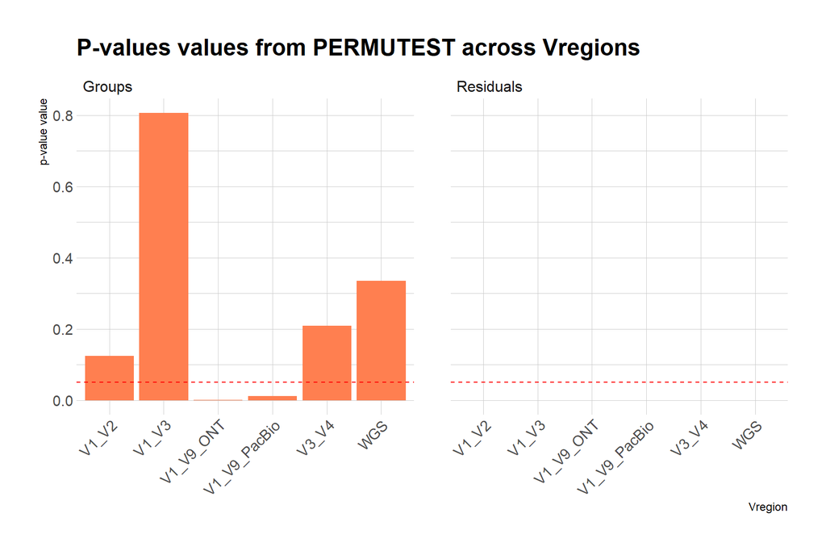

### 2.7.6 ANOVA on and subsequent Tukey post-hoc multiple comparisons of means (95% family-wise confidence level)

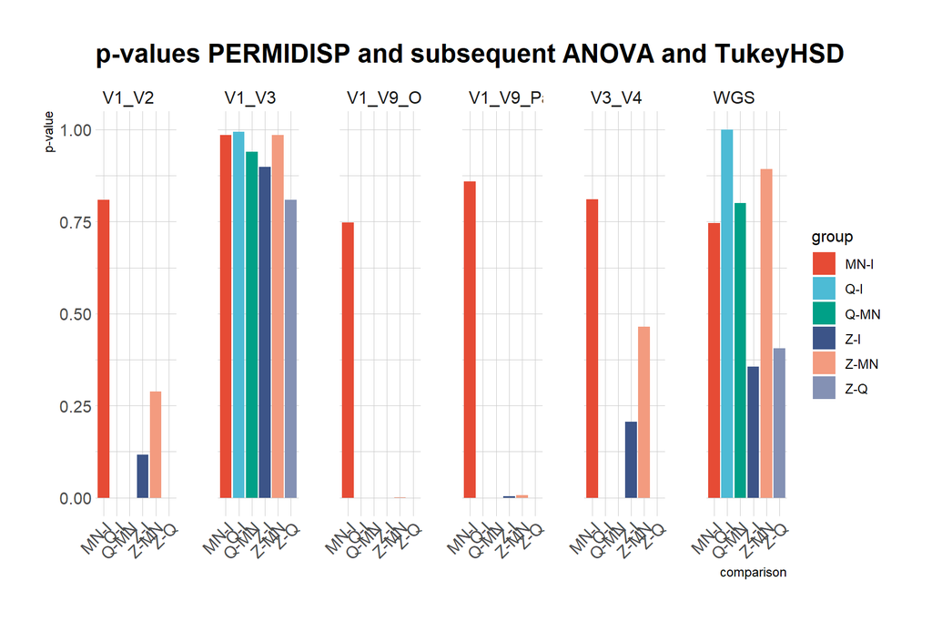

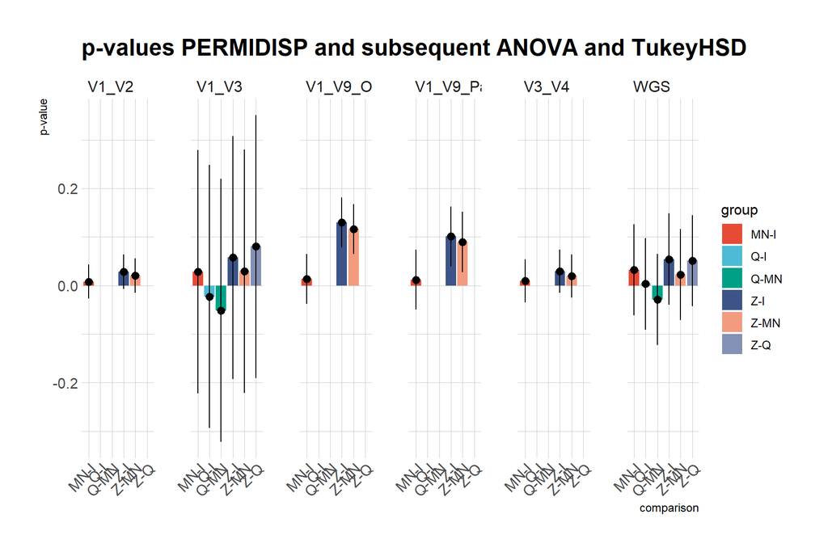

### 2.7.7 Difference bettween PERMANOVA and Permutation test restuls

| Vregion | F_PERMANOVA | F_Permutation | F_difference | Pr..F._PERMANOVA | Pr..F._Permutation | p_difference |
| --- | --- | --- | --- | --- | --- | --- |
| V1_V2 | 16.897736 | 2.6780567 | 14.219679 | 0.001 | 0.1238 | 0.1228 |
| V1_V2 | 16.897736 | NA | NA | 0.001 | NA | NA |
| V1_V2 | NA | 2.6780567 | NA | NA | 0.1238 | NA |
| V1_V2 | NA | NA | NA | NA | NA | NA |
| V1_V2 | NA | 2.6780567 | NA | NA | 0.1238 | NA |
| V1_V2 | NA | NA | NA | NA | NA | NA |
| V1_V3 | 6.248737 | 0.3111101 | 5.937627 | 0.001 | 0.8060 | 0.8050 |
| V1_V3 | 6.248737 | NA | NA | 0.001 | NA | NA |
| V1_V3 | NA | 0.3111101 | NA | NA | 0.8060 | NA |
| V1_V3 | NA | NA | NA | NA | NA | NA |
| V1_V3 | NA | 0.3111101 | NA | NA | 0.8060 | NA |
| V1_V3 | NA | NA | NA | NA | NA | NA |
| V1_V9_ONT | 17.055861 | 29.8988054 | 12.842944 | 0.001 | 0.0010 | 0.0000 |
| V1_V9_ONT | 17.055861 | NA | NA | 0.001 | NA | NA |
| V1_V9_ONT | NA | 29.8988054 | NA | NA | 0.0010 | NA |
| V1_V9_ONT | NA | NA | NA | NA | NA | NA |
| V1_V9_ONT | NA | 29.8988054 | NA | NA | 0.0010 | NA |
| V1_V9_ONT | NA | NA | NA | NA | NA | NA |
| V1_V9_PacBio | 23.365574 | 12.4871179 | 10.878456 | 0.001 | 0.0120 | 0.0110 |
| V1_V9_PacBio | 23.365574 | NA | NA | 0.001 | NA | NA |
| V1_V9_PacBio | NA | 12.4871179 | NA | NA | 0.0120 | NA |
| V1_V9_PacBio | NA | NA | NA | NA | NA | NA |
| V1_V9_PacBio | NA | 12.4871179 | NA | NA | 0.0120 | NA |
| V1_V9_PacBio | NA | NA | NA | NA | NA | NA |
| V3_V4 | 22.733270 | 1.7902607 | 20.943009 | 0.001 | 0.2090 | 0.2080 |
| V3_V4 | 22.733270 | NA | NA | 0.001 | NA | NA |
| V3_V4 | NA | 1.7902607 | NA | NA | 0.2090 | NA |
| V3_V4 | NA | NA | NA | NA | NA | NA |
| V3_V4 | NA | 1.7902607 | NA | NA | 0.2090 | NA |
| V3_V4 | NA | NA | NA | NA | NA | NA |
| WGS | 83.755046 | 1.3208991 | 82.434147 | 0.001 | 0.3350 | 0.3340 |
| WGS | 83.755046 | NA | NA | 0.001 | NA | NA |
| WGS | NA | 1.3208991 | NA | NA | 0.3350 | NA |
| WGS | NA | NA | NA | NA | NA | NA |
| WGS | NA | 1.3208991 | NA | NA | 0.3350 | NA |
| WGS | NA | NA | NA | NA | NA | NA |

## 2.8 Comparison across all DNA isolation methods

### 2.8.1 PERMANOVA

Carry out PERMANOVA with combined model (DNA_isolation_kit + Vregion)

### 2.8.2 Full-model PERMANOVA

|  | Df | SumOfSqs | R2 | F | Pr(>F) |
| --- | --- | --- | --- | --- | --- |
| DNA_isolation_method | 3 | 4.369147 | 0.2447982 | 37.44263 | 0.001 |
| library | 5 | 10.756064 | 0.6026496 | 55.30626 | 0.001 |
| Residual | 70 | 2.722746 | 0.1525522 | NA | NA |
| Total | 78 | 17.847957 | 1.0000000 | NA | NA |

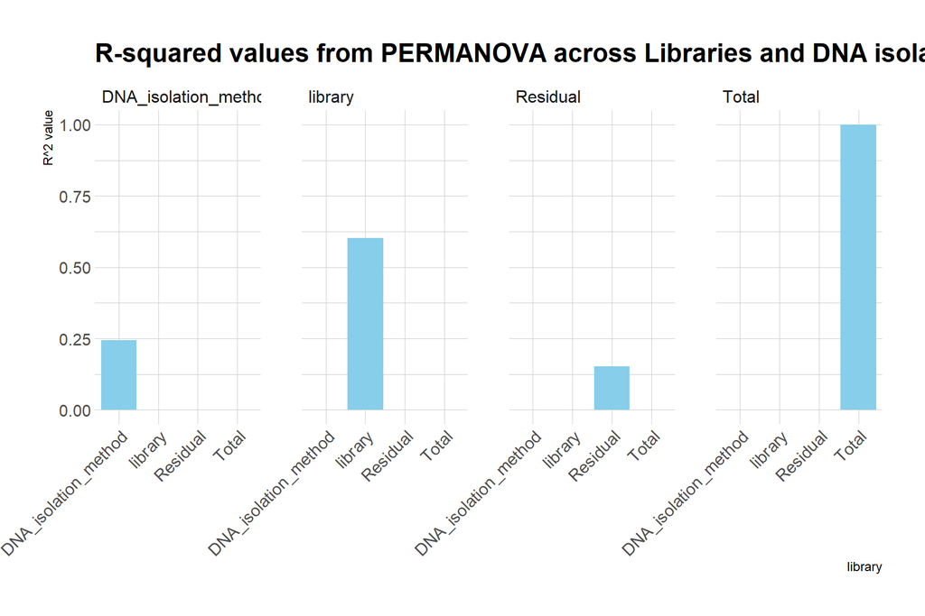

The R2 values indicate the proportion of variation explained by the groups. A higher R2 suggests that the grouping factor (in this case, the DNA isolation method) explains a larger proportion of the variation in the data.

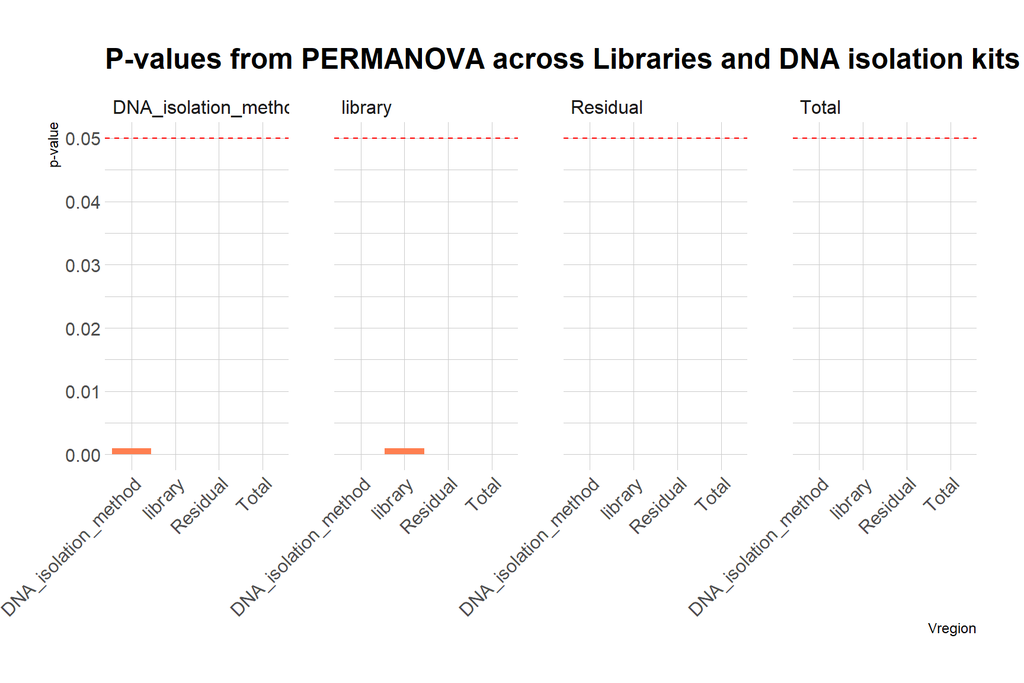

A p-value less than 0.05, indicate that the centroids of the groups in the multivariate space are significantly different.

### 2.8.3 PairWise PERMANOVA

| pairs | Df | SumsOfSqs | F.Model | R2 | p.value | p.adjusted | sig |
| --- | --- | --- | --- | --- | --- | --- | --- |
| I vs MN | 1 | 0.0990717 | 0.5116353 | 0.0110002 | 0.733 | 1.000 |  |
| I vs Z | 1 | 1.4392050 | 7.9365415 | 0.1471459 | 0.001 | 0.006 | * |
| I vs Q | 1 | 2.5533815 | 14.1394621 | 0.3277617 | 0.001 | 0.006 | * |
| MN vs Z | 1 | 1.2445146 | 6.9459894 | 0.1311901 | 0.001 | 0.006 | * |
| MN vs Q | 1 | 2.5353738 | 14.3123996 | 0.3304458 | 0.001 | 0.006 | * |
| Z vs Q | 1 | 1.7366840 | 11.0169400 | 0.2753069 | 0.001 | 0.006 | * |

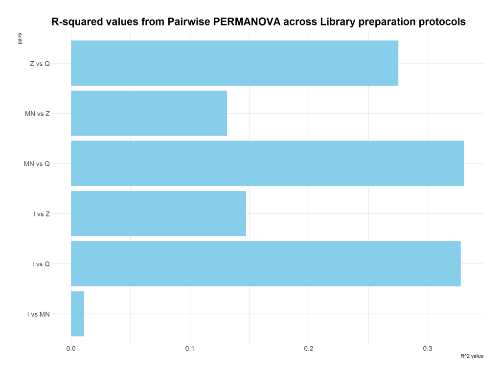

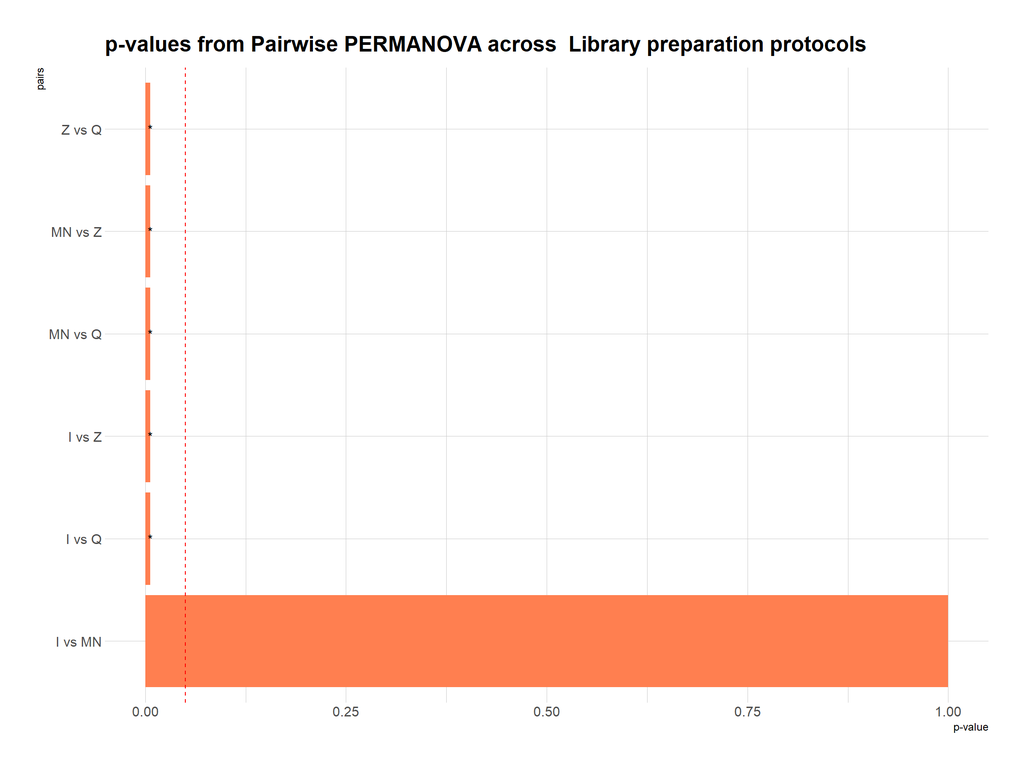

### 2.8.4 PERMDISP2

```
##
##  Homogeneity of multivariate dispersions
##
## Call: betadisper(d = dis, group = groups)
##
## No. of Positive Eigenvalues: 45
## No. of Negative Eigenvalues: 33
##
## Average distance to median:
##      I     MN      Q      Z
## 0.4305 0.4255 0.2858 0.3944
##
## Eigenvalues for PCoA axes:
## (Showing 8 of 78 eigenvalues)
##  PCoA1  PCoA2  PCoA3  PCoA4  PCoA5  PCoA6  PCoA7  PCoA8
## 4.8288 3.4315 2.8049 2.1177 1.3324 1.0824 0.5501 0.4938
```

### 2.8.5 ANOVA on test results

|  | Df | Sum Sq | Mean Sq | F value | Pr(>F) |
| --- | --- | --- | --- | --- | --- |
| Groups | 3 | 0.1277911 | 0.0425970 | 4.886789 | 0.0037091 |
| Residuals | 75 | 0.6537582 | 0.0087168 | NA | NA |

### 2.8.6 Permutation test for F

```
##
## Permutation test for homogeneity of multivariate dispersions
## Permutation: free
## Number of permutations: 999
##
## Response: Distances
##           Df  Sum Sq  Mean Sq      F N.Perm Pr(>F)
## Groups     3 0.12779 0.042597 4.8868    999  0.005 **
## Residuals 75 0.65376 0.008717
## ---
## Signif. codes:  0 '***' 0.001 '**' 0.01 '*' 0.05 '.' 0.1 ' ' 1
##
## Pairwise comparisons:
## (Observed p-value below diagonal, permuted p-value above diagonal)
##           I       MN        Q     Z
## I           0.768000 0.016000 0.075
## MN 0.758723          0.021000 0.122
## Q  0.011199 0.014826          0.077
## Z  0.062137 0.113799 0.066174
```

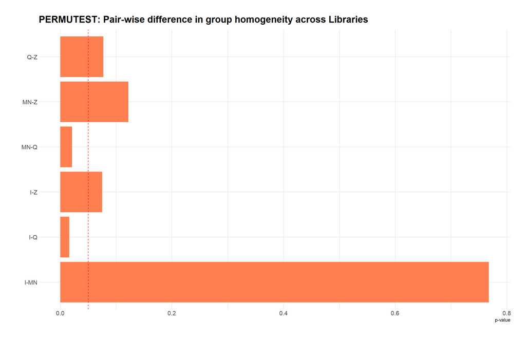

### 2.8.7 Tukey’s Honest Significant Differences

```
##   Tukey multiple comparisons of means
##     95% family-wise confidence level
##
## Fit: aov(formula = distances ~ group, data = df)
##
## $group
##              diff         lwr         upr     p adj
## MN-I -0.005023328 -0.07584126  0.06579460 0.9976829
## Q-I  -0.144669033 -0.25004948 -0.03928858 0.0030568
## Z-I  -0.036137444 -0.10695537  0.03468048 0.5401799
## Q-MN -0.139645705 -0.24502615 -0.03426526 0.0045379
## Z-MN -0.031114116 -0.10193204  0.03970381 0.6571814
## Z-Q   0.108531589  0.00315114  0.21391204 0.0410624
```

### 2.8.8 PCoA and distances to centroid for each group

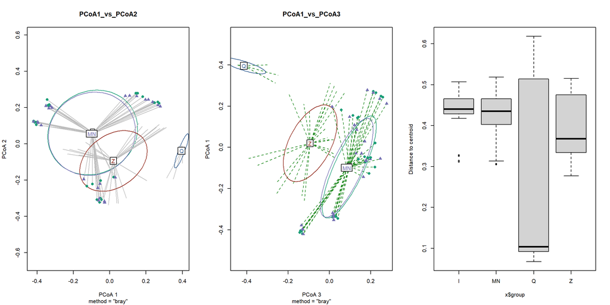

## 2.9 PERMANOVA on MN and I only

Carry out PERMANOVA with combined model (DNA_isolation_kit + Vregion)

|  | Df | SumOfSqs | R2 | F | Pr(>F) |
| --- | --- | --- | --- | --- | --- |
| DNA_isolation_method | 1 | 0.0990717 | 0.0110002 | 5.967973 | 0.001 |
| library | 5 | 8.2266961 | 0.9134287 | 99.113449 | 0.001 |
| Residual | 41 | 0.6806232 | 0.0755711 | NA | NA |
| Total | 47 | 9.0063909 | 1.0000000 | NA | NA |

| pairs | Df | SumsOfSqs | F.Model | R2 | p.value | p.adjusted | sig |
| --- | --- | --- | --- | --- | --- | --- | --- |
| I vs MN | 1 | 0.0990717 | 0.5116353 | 0.0110002 | 0.747 | 0.747 |  |

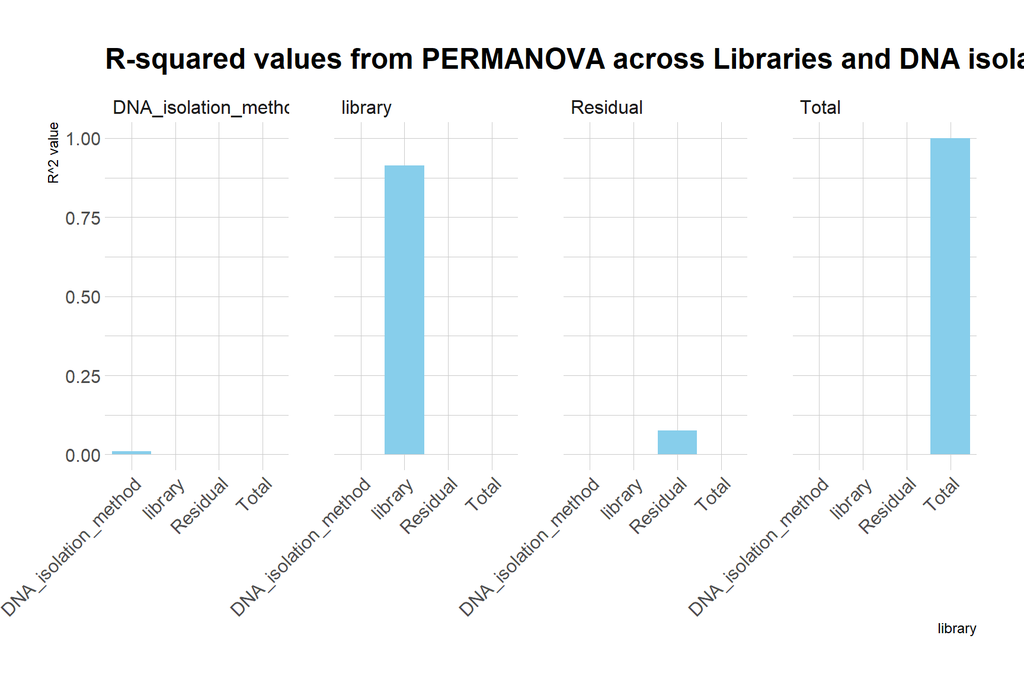

The R2 values indicate the proportion of variation explained by the groups. A higher R2 suggests that the grouping factor (in this case, the DNA isolation method) explains a larger proportion of the variation in the data.

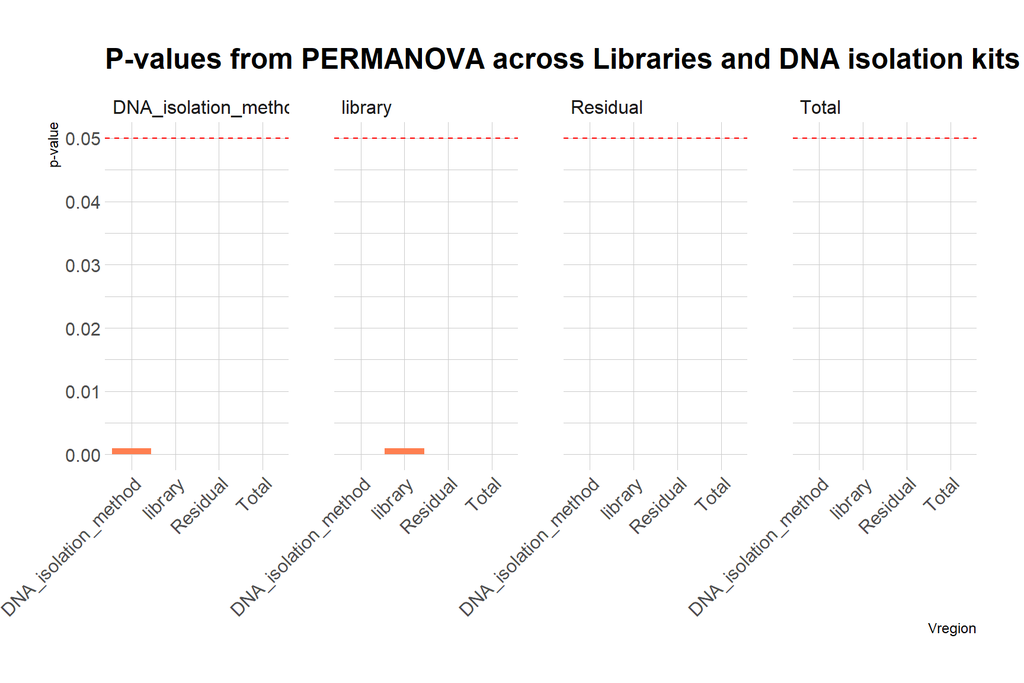

A p-value less than 0.05, indicate that the centroids of the groups in the multivariate space are significantly different.

### 2.9.1 PERMDISP2

```
##
##  Homogeneity of multivariate dispersions
##
## Call: betadisper(d = dis, group = groups)
##
## No. of Positive Eigenvalues: 30
## No. of Negative Eigenvalues: 17
##
## Average distance to median:
##      I     MN
## 0.4306 0.4255
##
## Eigenvalues for PCoA axes:
## (Showing 8 of 47 eigenvalues)
##   PCoA1   PCoA2   PCoA3   PCoA4   PCoA5   PCoA6   PCoA7   PCoA8
## 3.30207 2.65845 1.12483 0.89599 0.36499 0.26515 0.11481 0.09787
```

### 2.9.2 ANOVA on test results

|  | Df | Sum Sq | Mean Sq | F value | Pr(>F) |
| --- | --- | --- | --- | --- | --- |
| Groups | 1 | 0.0003059 | 0.0003059 | 0.0940721 | 0.7604469 |
| Residuals | 46 | 0.1495811 | 0.0032518 | NA | NA |

### 2.9.3 Permutation test for F

```
##
## Permutation test for homogeneity of multivariate dispersions
## Permutation: free
## Number of permutations: 999
##
## Response: Distances
##           Df   Sum Sq   Mean Sq      F N.Perm Pr(>F)
## Groups     1 0.000306 0.0003059 0.0941    999  0.765
## Residuals 46 0.149581 0.0032518
##
## Pairwise comparisons:
## (Observed p-value below diagonal, permuted p-value above diagonal)
##          I    MN
## I          0.771
## MN 0.76045
```

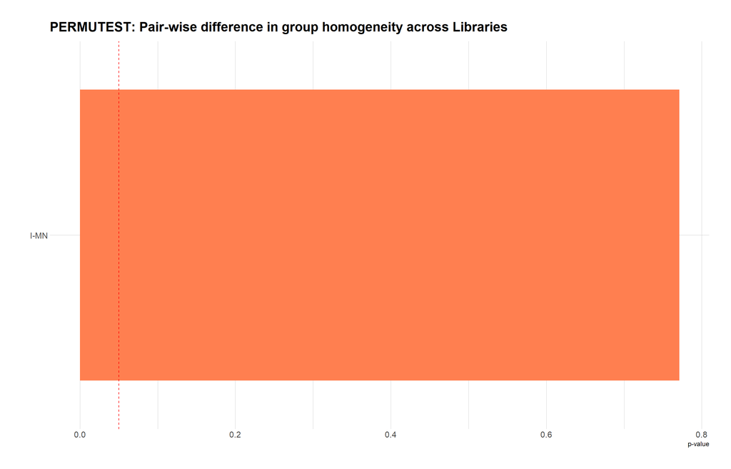

### 2.9.4 Tukey’s Honest Significant Differences

```
##   Tukey multiple comparisons of means
##     95% family-wise confidence level
##
## Fit: aov(formula = distances ~ group, data = df)
##
## $group
##              diff         lwr        upr     p adj
## MN-I -0.005048928 -0.03818416 0.02808631 0.7604469
```

### 2.9.5 PCoA and distances to centroid for each group

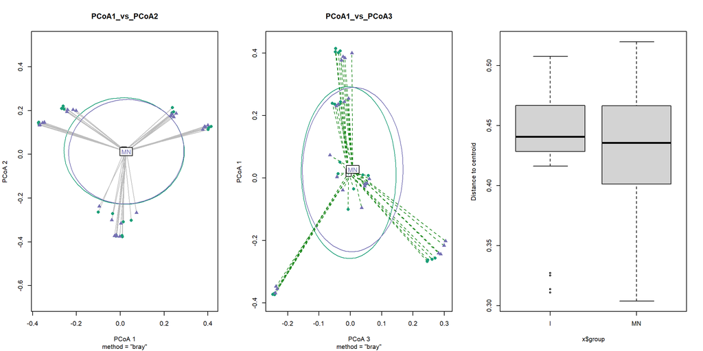